# Hand Sanitizer

3/6/2020

## Context

- After hand sanitizer was installed, nurses underwent a training program to use hand sanitizers.
- Before the program, in 51 visits, hand sanitizer was used 13 times.
- After two months, when revisiting the nurses, in 56 visits, 50 of them involved hand sanitizer.
- Question: How much did they improve?

## How much did they improve?

- We can approximate this by calculating p, the probability a nurse will use hand sanitizer.
- In the first study, the proportion of nurses that used hand sanitizer was 13/51, about ~25.4%.
- After the study, the proportion was 50/56, which is about 89%.
- However, we can do better. Using a Bayesian approach, we can find a probability that incorporates both experiments

## Incorporating Bayes’ Law

- In this case, we’re looking at a problem with a fixed number of studies, a success case, and a failure case.
- We can use a binomial distribution, with parameters n, the number of cases, and p, the probability of success. We also now X, the number of successes, or out data.
- We can look closer using Bayes Law, which compares our data, X, our likelihood, X given p (or \(P(X|P)\)) and our prior information for our probability, \(P(p)\).

\[ P(p|X) \propto P(X|p)*P(p) \] - So, to move forward, we need to find our likelihood and prior information.

## Conjugate Priors

- The likelihood of a binomial distribution is \(P(X|p) \propto p^{x}(1-p)^{n-x}\).
- We can incorporate prior information by using conjugate priors. This allows us to incorporate prior information in a very easy manner.
- First, we can take terms with data in our likelihood and turn them into parameters. Our data is x and n, since p is an underlying component.
- This gives us a distribution \(P(p) \propto p^{\alpha-1}(1-p)^{\beta-1}\). This is the beta distribution with parameters \(\alpha\) and \(\beta\), the conjugate prior for the binomial distribution!

## Prior to Posterior

- To find our posterior, we can refer back to Bayes Law, \(P(p|X) \propto P(X|p)*P(p)\).
- We can plug in our likelihood and posterior to find that \[ P(p|X) \propto p^{x}(1-p)^{n-x} p^{\alpha-1}(1-p)^{\beta-1}\] \[ P(p|X) \propto p^{x+\alpha-1}(1-p)^{n-x+\beta-1}\]
- This, once again, is a beta distribution, \(p^{a-1} + (1-p)^{b-1}\) with paramters \(a = x+ \alpha\) and \(b =n-x+\beta\). In other words, it’s comparing the number of successes and failures, adjusted by prior information parameters \(alpha\) and \(beta\).

## Simulating posterior with uninformative prior

[figure not shown]

## Simulating posterior with uninformative prior

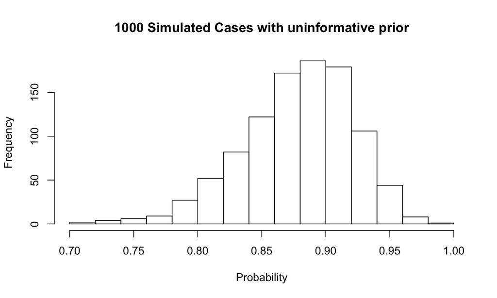

## Incorporating past study into prior

- We can also use the initial study’s data as prior information.
- In their study, they had 13 successes out of 51 cases. This can be approximated with prior parameters \(\alpha=13\) and \(\beta = 51-13=38\).
- This would lead to a conjugate beta with parameters \(a = 50 + 13 = 63\) and \(b = 6 + 38 = 44\). This distribution would have a mean of \(\frac{63}{63+44} = 0.59\), and a mode of \(\frac{63-1}{63+44-2} =0.59\).
- Like last time, we can make 1000 simulations from a beta distribution in R with our \(a\) and \(b\) parametres.

## Simulating Posterior with Information

- Our simulation has a mean 0.5901243, which is close to our estimated mean of 0.59. We can also see in our plot below that a lot of the information is captured around 0.6.

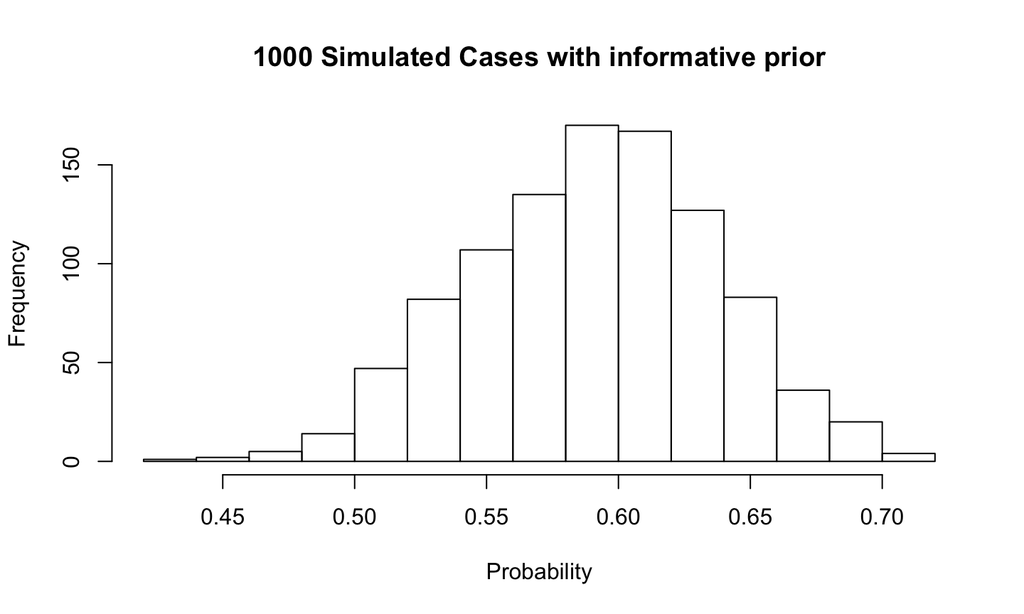

## Conclusions.

- We analyzed the probability of nurses using hand sanitizer from these problems using an uniformative and informative case with Bayesian likelihood and conjugate priors.
- With no prior information, we estimated a mean probability of 0.88. With information from the past experiment, we estimated a mean probability 0.59.
- Both of these distributions show a major improvement from the original rate of 0.25. However, the “informed” prior is lower, effectively simply updating the first experiment with the second one.
- As successful cases and studies continue, the posterior can continue to be updated to incorporate both past data and current data.